# Analýza predaja autosedačiek

Sofia Snopková

2025-12-02

# 1.Príprava dát

Najprv si stiahneme potrebné knižnice, s ktorými budeme v projekte pracovať. Cieľom projektu je analyzovať, ktoré faktory ovplyvňujú predaje autosedačiek (Sales) a vytvoriť predikčný model.

```r
library(ISLR)
library(tidyverse)
library(rsample)
library(car)
#import datasetu Carseats z knižnice ISLR
data(Carseats)
```

```r
#Načítanie datasetu do premennej na následné spracovanie, úpravu a analýzu
seats <- Carseats
summary(seats)
```

```
##      Sales          CompPrice       Income        Advertising
##  Min.   : 0.000   Min.   : 77   Min.   : 21.00   Min.   : 0.000
##  1st Qu.: 5.390   1st Qu.:115   1st Qu.: 42.75   1st Qu.: 0.000
##  Median : 7.490   Median :125   Median : 69.00   Median : 5.000
##  Mean   : 7.496   Mean   :125   Mean   : 68.66   Mean   : 6.635
##  3rd Qu.: 9.320   3rd Qu.:135   3rd Qu.: 91.00   3rd Qu.:12.000
##  Max.   :16.270   Max.   :175   Max.   :120.00   Max.   :29.000
##    Population        Price        ShelveLoc        Age          Education
##  Min.   : 10.0   Min.   : 24.0   Bad   : 96   Min.   :25.00   Min.   :10.0
##  1st Qu.:139.0   1st Qu.:100.0   Good  : 85   1st Qu.:39.75   1st Qu.:12.0
##  Median :272.0   Median :117.0   Medium:219   Median :54.50   Median :14.0
##  Mean   :264.8   Mean   :115.8                Mean   :53.32   Mean   :13.9
##  3rd Qu.:398.5   3rd Qu.:131.0                3rd Qu.:66.00   3rd Qu.:16.0
##  Max.   :509.0   Max.   :191.0                Max.   :80.00   Max.   :18.0
##  Urban       US
##  No :118   No :142
##  Yes:282   Yes:258
##
##
##
##
```

# 2.Exploratívna analýza (EDA)

V ďalšom kroku skontrolujeme, či sa v našom datasete nachádzajú nejaké prázdne hodnoty, ktoré by bolo treba doplniť. Zatiaľ z datasetu neodstraňujeme žiadne premenné, pretože každá z nich by mohla mať významný vplyv na predaj sedačiek a mohla by byť potrebná pri našej analýze.

```r
colSums(is.na(seats))
```

```
##       Sales   CompPrice      Income Advertising  Population       Price
##           0           0           0           0           0           0
##   ShelveLoc         Age   Education       Urban          US
##           0           0           0           0           0
```

Z výstupu môžeme vidieť, že sa v našom datasete nenachádzajú žiadne NA, čiže prázdne hodnoty.

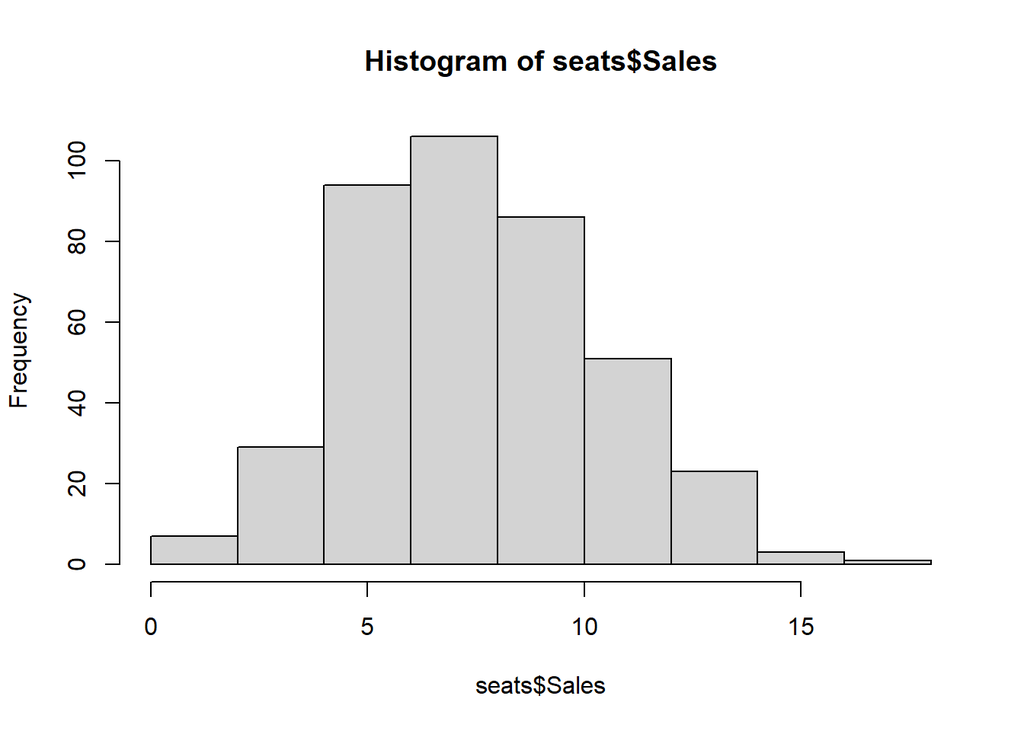

```r
hist(seats$Sales)
```

Z histogramu vidíme, že najviac obchodov v datasete predalo autosedačky od 5 do 10 tisíc kusov.

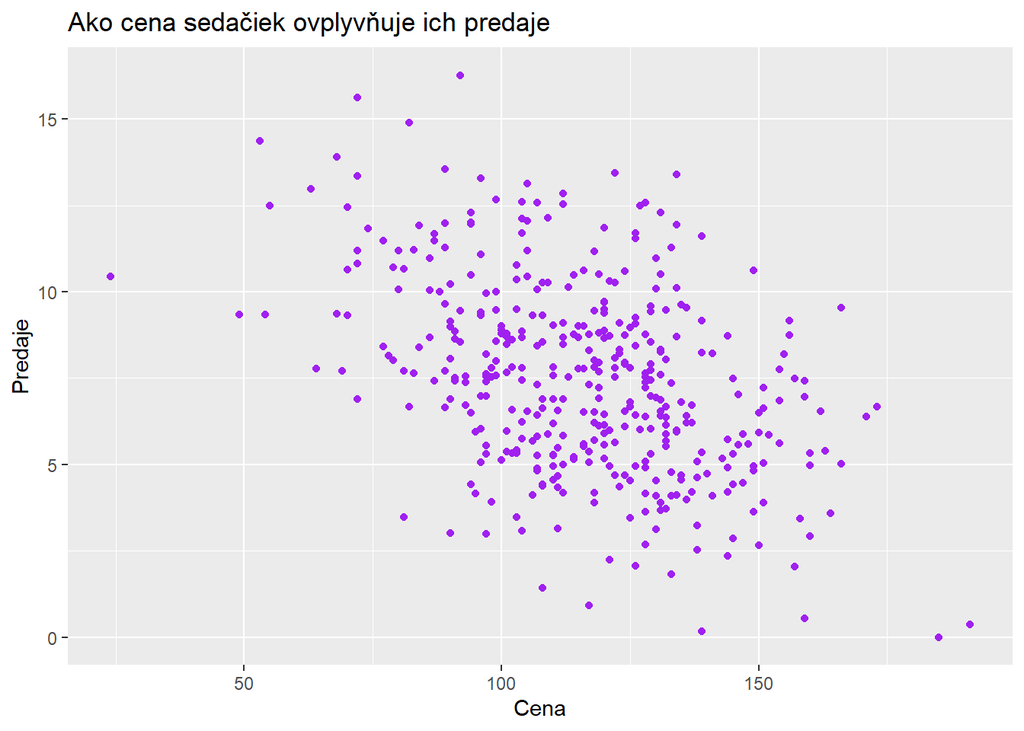

```r
ggplot(seats, aes(x = Price, y = Sales)) +
  geom_point(color = "purple") +
  labs(title = "Ako cena sedačiek ovplyvňuje ich predaje",
       x = "Cena", y = "Predaje")
```

Z grafu vidíme, že ako cena sedačiek stúpa, predaje klesajú.Vyskytuje sa pár anomálií, ako napríklad že dva razy boli mali predaje vyššiu hodnotu ako 15, a to keď cena sa pohybovala okolo 75 a 100, pričom táto cena nie je najnižšia z histórie obchodov.

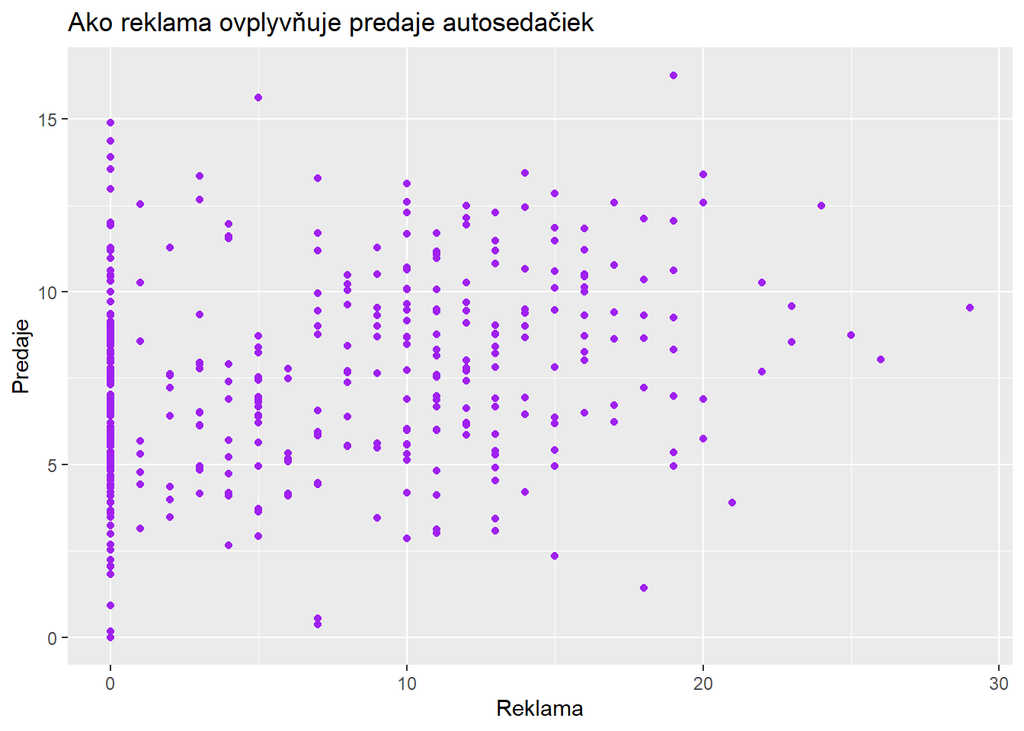

```r
ggplot(seats, aes(x = Advertising, y = Sales)) +
  geom_point(color = "purple") +
  labs(title = "Ako reklama ovplyvňuje predaje autosedačiek",
       x = "Reklama", y = "Predaje")
```

Vidíme, že vzťah reklama - predaje je slabý až stredný. Najväčší rozptyl predajov je pri hodnote reklamy 0, čo znamená, že veľa obchodov míňa veľmi málo na reklamu. Predaje sa tu veľmi líšia, čiže reklama nie je jediný faktor, ktorý ich ovplyvňuje. Pri vyššej reklame (15 - 30) vidíme, že počet bodov sa znižuje (menej obchodov míňa na reklamu), ale predaje sa mierne zvyšujú. Vieme povedať, že reklama má pozitívny, ale nie silný efekt na predaje.

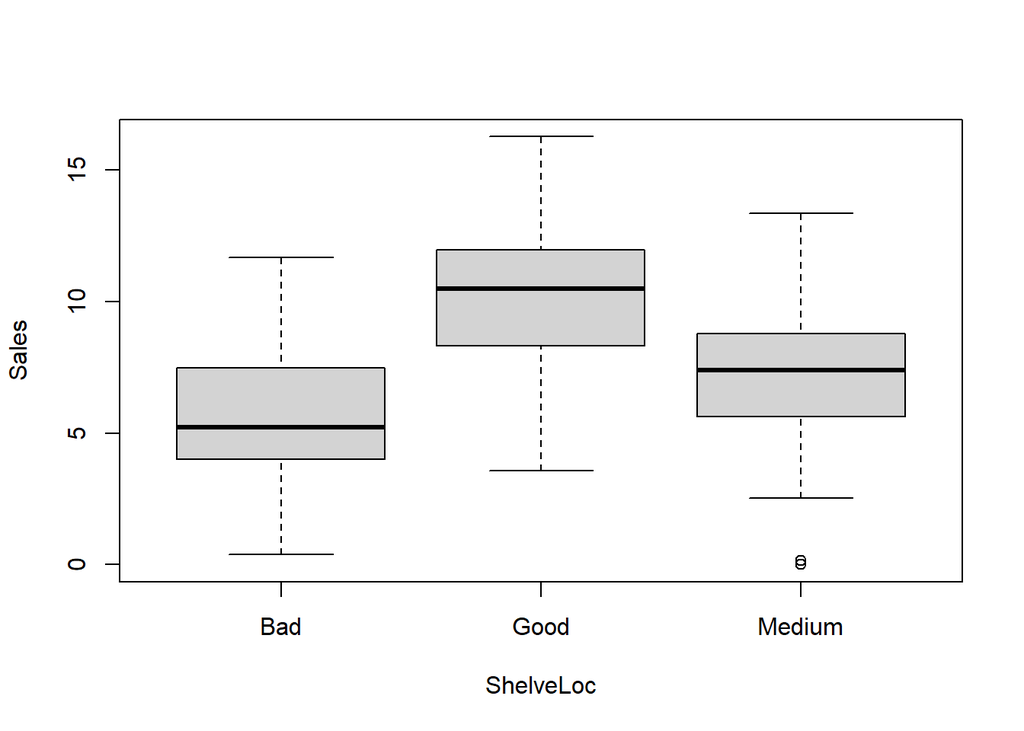

```r
boxplot(Sales ~ ShelveLoc, data = seats)
```

Nasledujúci graf znázorňuje vzťah medzi predajmi a kvalitou umiestnenia autosedačky na poličke. Povedzme, že autosedačka je umiestnená na úrovní očí, čo je ideálna pozícia, dostane hodnotu “Good”. Ak je príliš vysoko, “Bad”, atď. Z grafu vidíme, že najviac predajov sa uskutočnilo, keď autosedačky boli na pozícií “Good”, stredne, keď na “Medium” a najmenej, keď boli na pozícií “Bad”. Z tohto zistenia môžme povedať, že pozícia na polici, kde je autosedačka umiestnená, ovplyvňuje jej predaj. Ako nasledujúci krok vyberieme všetky numerické hodnoty a zistíme koreláciu medzi nimi.

```r
num <- seats %>% select_if(is.numeric)
cor(num)
```

```
##                   Sales   CompPrice       Income  Advertising   Population
## Sales        1.00000000  0.06407873  0.151950979  0.269506781  0.050470984
## CompPrice    0.06407873  1.00000000 -0.080653423 -0.024198788 -0.094706516
## Income       0.15195098 -0.08065342  1.000000000  0.058994706 -0.007876994
## Advertising  0.26950678 -0.02419879  0.058994706  1.000000000  0.265652145
## Population   0.05047098 -0.09470652 -0.007876994  0.265652145  1.000000000
## Price       -0.44495073  0.58484777 -0.056698202  0.044536874 -0.012143620
## Age         -0.23181544 -0.10023882 -0.004670094 -0.004557497 -0.042663355
## Education   -0.05195524  0.02519705 -0.056855422 -0.033594307 -0.106378231
##                   Price          Age    Education
## Sales       -0.44495073 -0.231815440 -0.051955242
## CompPrice    0.58484777 -0.100238817  0.025197050
## Income      -0.05669820 -0.004670094 -0.056855422
## Advertising  0.04453687 -0.004557497 -0.033594307
## Population  -0.01214362 -0.042663355 -0.106378231
## Price        1.00000000 -0.102176839  0.011746599
## Age         -0.10217684  1.000000000  0.006488032
## Education    0.01174660  0.006488032  1.000000000
```

Z korelačnej tabuľky sa zameriame hlavne na hodnoty Price, Age, Advertising a Income. CompPrice, Population a Education majú hodnoty veľmi blízko nule, čo znamená, že nemajú takmer žiadny efekt na predaje autosedačiek. Začneme teda od najsilnejšej k najslabšej.

Price - má hodnotu približne -0.445, čo vyjadruje stredne silnú negatívnu koreláciu. Je to taktiež ekonomicky logické. Čím vyššia bude cena produktu, tým menej ľudí si ho kúpi.

Advertising - má hodnotu 0.27, čiže slabšia pozitívna korelácia, čo znamená, čím viac sa minie na reklamu, tým budú vyššie predaje. Ale korelácia je iba mierna. Reklama pomáha, ale má limitovaný účinok.

Age - má hodnotu -0.232, čo vyjadruje slabú až strednú negatívnu koreláciu. Je to pomerne logické, keďže s vyšším vekom populácie okolo obchodu budú predaje mierne klesať.

Income - má hodnotu 0.15, čo vyjadruje slabú pozitívnu koreláciu, čiže čím bohatšia oblasť, tým vyššie predaje. Vplyv je síce slabý, ale nie nulový.

Ďalej, premenné ShelveLoc, Urban, US si faktorujeme:

```r
#Faktorizácia premenných
seats$ShelveLoc <- factor(seats$ShelveLoc)
seats$Urban <- factor(seats$Urban)
seats$US <- factor(seats$US)
```

Vytvoríme si regresný model, ktorý bude skúmať, ktoré premenné sú významné a ktoré nie. V modeli budeme odhadovať predaje (Sales) na základe premenných Price, Advertising, Income, Age a ShelveLoc.

# 3.Lineárny model

```r
lm_model <- lm(Sales ~ Price + Advertising + Income + Age + ShelveLoc,
               data = seats)
summary(lm_model)
```

```
##
## Call:
## lm(formula = Sales ~ Price + Advertising + Income + Age + ShelveLoc,
##     data = seats)
##
## Residuals:
##     Min      1Q  Median      3Q     Max
## -3.7968 -0.9912 -0.1068  0.9670  4.2404
##
## Coefficients:
##                  Estimate Std. Error t value Pr(>|t|)
## (Intercept)     13.400594   0.545299  24.575  < 2e-16 ***
## Price           -0.060559   0.003285 -18.436  < 2e-16 ***
## Advertising      0.105665   0.011642   9.076  < 2e-16 ***
## Income           0.013550   0.002771   4.891 1.47e-06 ***
## Age             -0.049826   0.004790 -10.401  < 2e-16 ***
## ShelveLocGood    4.875602   0.230253  21.175  < 2e-16 ***
## ShelveLocMedium  2.004566   0.189280  10.590  < 2e-16 ***
## ---
## Signif. codes:  0 '***' 0.001 '**' 0.01 '*' 0.05 '.' 0.1 ' ' 1
##
## Residual standard error: 1.539 on 393 degrees of freedom
## Multiple R-squared:  0.7074, Adjusted R-squared:  0.7029
## F-statistic: 158.3 on 6 and 393 DF,  p-value: < 2.2e-16
```

Vidíme, že R-squared vyšlo 0.7074, čo znamená, že model vysvetľuje 70.74% variability predajov. Priemerná odhadová chyba je 1.539 jednotky predajov a výsledky celkového F-testu značia, že model je veľmi významný ako celok. Jednotlivé odhady premenných hovoria že:

Price má hodnotu -0.0606, čiže každé zvýšenie ceny o 1 jednotku, predaje klesnú o 0.0606

Advertising má hodnotu 0.1057, čiže každá jednotka reklamy navyše predaje stúpnu o 0.1057

Income má hodnotu 0.0136, čiže v oblastiach, kde majú ľudia priemerne vyšší príjem viac kupujú -> zvyšujú sa predaje. Avšak efekt je menší než pri reklame či cene, ale stály významný.

Age má hodnotu -0.0498, čiže oblasti s vyšším vekovým priemerom kupujú menej -> predaje sú nižšie, čo znamená, že starší ľudia menej nakupujú autosedačky

ShelveLoc, čiže umiestnenie tovari na polici, je najsilnejšia premenná v modeli. Pokiaľ bude pozícia tovaru umiestnená na dobrej pozícií (Good), predaje sú v priemere o 4.88 jednotiek vyššie než pri “Bad”. Pri pozícií Medium stúpnu predaje o 2.005 oproti Bad.

Prakticky povedané, najviac predajov robí dobré umiestnenie tovaru v obchode, vyššia cena tovaru má silný negatívny efekt na predaje, reklama a príjem pomáhajú, ale mierne a staršia populácia kupuje menej autosedačiek.

Ako nasledovný krok si spravíme vif test, na zistenie multikolinearity v modeli:

```r
#Výsledok vif testu si uložíme do premennej, ktorú následne zobrazíme pomocou príkazu print()
vif <- vif(lm_model)
print(vif)
```

```
##                 GVIF Df GVIF^(1/(2*Df))
## Price       1.018505  1        1.009210
## Advertising 1.009404  1        1.004691
## Income      1.012469  1        1.006215
## Age         1.014095  1        1.007023
## ShelveLoc   1.014783  2        1.003676
```

Všetky hodnoty sú prakticky 1, čo znamená že v našom modeli multikolinearita neexistuje. Ďalším krokom v našej analýze sú predikcie.

# 4.Predikcie a metriky

```r
#Nastavíme seed, aby sme zaistili náhodnosť pri výbere dát do trénovacej a testovacej množiny
set.seed(123)

#Následne rozdelíme dáta do trénovacej a testovacej množiny
split <- initial_split(seats, prop = 0.7)
train <- training(split)
test <- testing(split)

#Vytvoríme model z trénovacej množiny dát
train_model <- lm(Sales ~ Price + Advertising + Income + ShelveLoc + Age, data = train)

summary(train_model)
```

```
##
## Call:
## lm(formula = Sales ~ Price + Advertising + Income + ShelveLoc +
##     Age, data = train)
##
## Residuals:
##    Min     1Q Median     3Q    Max
## -3.878 -1.074 -0.132  1.074  4.228
##
## Coefficients:
##                  Estimate Std. Error t value Pr(>|t|)
## (Intercept)     13.721934   0.676454  20.285  < 2e-16 ***
## Price           -0.060851   0.004211 -14.450  < 2e-16 ***
## Advertising      0.104190   0.014547   7.162 7.39e-12 ***
## Income           0.012054   0.003479   3.465 0.000616 ***
## ShelveLocGood    4.816996   0.287889  16.732  < 2e-16 ***
## ShelveLocMedium  1.978867   0.235301   8.410 2.31e-15 ***
## Age             -0.053157   0.006058  -8.775  < 2e-16 ***
## ---
## Signif. codes:  0 '***' 0.001 '**' 0.01 '*' 0.05 '.' 0.1 ' ' 1
##
## Residual standard error: 1.602 on 273 degrees of freedom
## Multiple R-squared:  0.6856, Adjusted R-squared:  0.6787
## F-statistic: 99.23 on 6 and 273 DF,  p-value: < 2.2e-16
```

Age má hodnotu -0.0531, čiže oblasti s vyšším vekovým priemerom kupujú menej -> predaje sú nižšie, čo znamená, že starší ľudia menej nakupujú autosedačky

```r
#Použijeme funkciu predict, aby sme predpovedali predaje na základe nášho trénovacieho modelu
pred <- predict(train_model, newdata = test)

#Keďže predpovedáme číselné hodnoty, vytvoríme si ďalšiu premennú, kde zostrojíme tabuľku, do ktorej pridáme hodnoty, ktoré predikoval náš model (predicted) a rozdiel medzi skutočnými hodnotami predaja (difference)
difference_table <- test
difference_table$predicted <- pred
difference_table$difference <- difference_table$Sales - difference_table$predicted
difference_table$index <- as.numeric(rownames(difference_table))

#Nakoniec vyberieme tri stĺpce a zobrazíme hodnoty
final_predict_table <- difference_table %>%
  select(Sales, predicted, difference)
head(final_predict_table)
```

```
##    Sales predicted difference
## 1   9.50  6.213276 3.28672369
## 3  10.06  9.160273 0.89972713
## 6  10.81  7.910993 2.89900712
## 8  11.85 10.214541 1.63545894
## 12 11.96 11.710937 0.24906292
## 15 11.17 11.150771 0.01922902
```

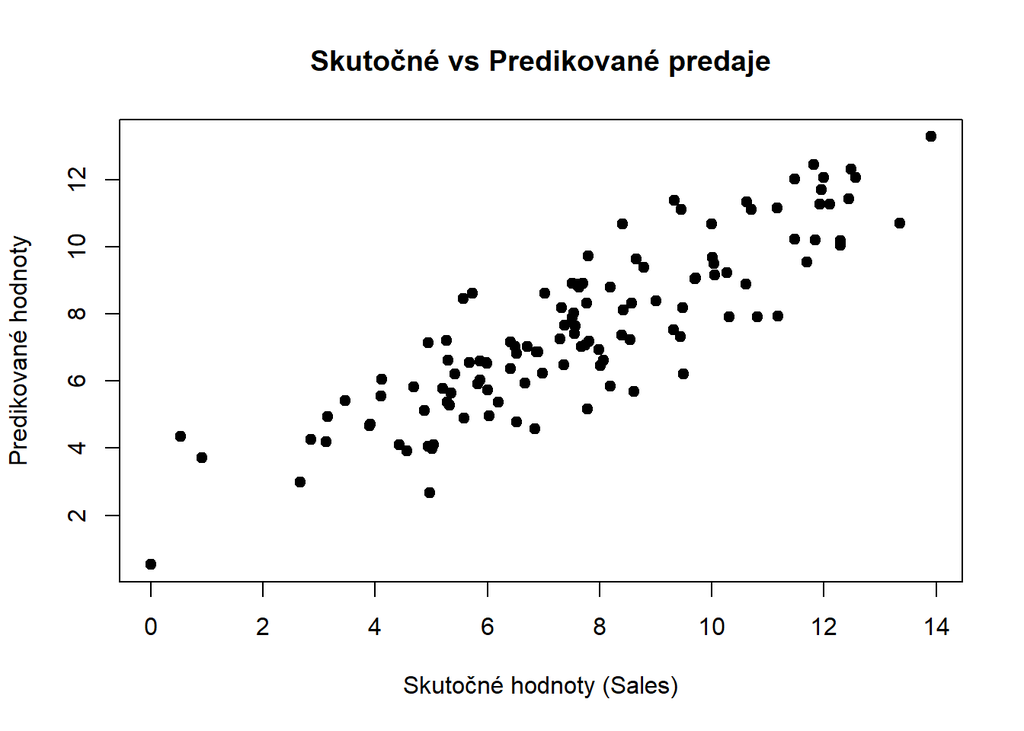

```r
plot(final_predict_table$Sales, final_predict_table$predicted,
     xlab = "Skutočné hodnoty (Sales)",
     ylab = "Predikované hodnoty",
     main = "Skutočné vs Predikované predaje",
     pch = 19)
```

Na grafe môžme vidieť skutočné hodnoty porovnané s tými predikovanými. Čím majú body väčší rozptyl, tým nepresnejší model je a čím viac sa podobá priamke, tým sú predikcie presnejšie.

```r
#Vyberieme riadky s indexami 1, 6 a 12 a odstránime štatisticky nevýznamné stĺpce
difference_table[difference_table$index %in% c(1,6, 12), !names(difference_table) %in% c("Population", "Education", "CompPrice", "Urban", "US")]
```

```
##    Sales Income Advertising Price ShelveLoc Age predicted difference index
## 1   9.50     73          11   120       Bad  42  6.213276  3.2867237     1
## 6  10.81    113          13    72       Bad  78  7.910993  2.8990071     6
## 12 11.96     94           4    94      Good  50 11.710937  0.2490629    12
```

```r
rmse <- sqrt(mean((pred - test$Sales)^2))
rmse
```

```
## [1] 1.39459
```

# 5.Záver

Cieľom projektu bolo analyzovať, ktoré faktory najvýraznejšie ovplyvňujú predaje detských autosedačiek a vytvoriť predikčný model schopný odhadovať predaje na základe dostupných charakteristík obchodov. Prvým významným výsledkom bolo, čo sme mohli očakávať aj z intuície: cena je najzásadnejší faktor, ktorý negatívne ovplyvňuje predaje. Vyššia cena znižuje dopyt, pričom tento efekt je stabilný v celom datasete. Naopak najsilnejší pozitívny vplyv má na predaje pozícia produktu na polici. Pokiaľ je dostupne umiestnený produkt na polici, obchody môžu vykazovať oveľa lepšie výsledky ako tie, ktoré majú produkty nevhodne umiestnené na polici. Čo bolo pomerne prekvapivé zistenie je, že reklama, síce má pozitívny vplyv na predaje, nie je príliš silný. Vyšší príjem mierne zvyšuje predaje a vyšší vek populácie má tendenciu predaje autosedačiek znižovať, čo je pomerne logické, keďže starší ľudia menej jazdia na autách.